# Hoop Analytics Powered by R

Chris Campbell

2025-02-21

# 1 Introduction

hooplyticsR, a data-driven project, analyzes basketball player performance using advanced statistical techniques and data visualization from the nbastatR package. It provides in-depth insights into player performance variability and trends by analyzing key metrics like points, rebounds, assists, and fantasy scores. The project aims to create an interactive platform for analyzing basketball data, identifying patterns, and supporting decision-making in player evaluation and fantasy basketball. hooplyticsR makes basketball data more accessible and actionable through statistical analysis and powerful visualizations.

# 2 Player Statistics

This section provides a detailed statistical overview of various basketball players based on their performance across multiple metrics. For each player, we calculate both average values and standard deviations for key performance indicators such as points, rebounds, assists, and fantasy scores. These calculations allow for an in-depth understanding of a player’s consistency and overall impact on the game.

## 2.1 Key Statistics Included

1. **Games Played**: The total number of games each player participated in.
2. **Average Points**: The player’s average points scored per game.
3. **Average Rebounds**: The average number of rebounds grabbed per game.
4. **Average Assists**: The average number of assists made per game.
5. **Average Points + Rebounds + Assists (PRA)**: A combined measure of points, rebounds, and assists to give a broader view of overall player contribution.
6. **Average 3-Point Field Goals Made**: The average number of successful three-pointers made per game.
7. **Average Steals + Blocks**: A combined statistic for steals and blocks, reflecting a player’s defensive impact.
8. **Average Turnovers**: The average number of turnovers committed per game.
9. **Average Fantasy Score**: A calculated fantasy score based on points, rebounds, assists, steals, blocks, and turnovers.
10. **Standard Deviation (SD) Values**: For each key metric, the standard deviation is provided, indicating how consistent the player is across games.

This summary is generated for each player, providing a clear and concise view of their performance and variability over time. The summary can be used to identify trends, strengths, and areas for improvement, and can be easily included in reports or further analysis.

### 2.1.1 Amen Thompson

[output not shown]

*The lower the standard deviation (SD), the more consistent the player is across games. A high SD indicates variability, suggesting the player’s performance is less predictable.*

*For instance, a low SD in points means the player typically scores within a narrow range, while a high SD might indicate fluctuating performance.*

### 2.1.2 Anthony Edwards

[output not shown]

*The lower the standard deviation (SD), the more consistent the player is across games. A high SD indicates variability, suggesting the player’s performance is less predictable.*

*For instance, a low SD in points means the player typically scores within a narrow range, while a high SD might indicate fluctuating performance.*

### 2.1.3 Desmond Bane

[output not shown]

*The lower the standard deviation (SD), the more consistent the player is across games. A high SD indicates variability, suggesting the player’s performance is less predictable.*

*For instance, a low SD in points means the player typically scores within a narrow range, while a high SD might indicate fluctuating performance.*

### 2.1.4 Giannis Antetokounmpo

[output not shown]

*The lower the standard deviation (SD), the more consistent the player is across games. A high SD indicates variability, suggesting the player’s performance is less predictable.*

*For instance, a low SD in points means the player typically scores within a narrow range, while a high SD might indicate fluctuating performance.*

### 2.1.5 Karl-Anthony Towns

[output not shown]

*The lower the standard deviation (SD), the more consistent the player is across games. A high SD indicates variability, suggesting the player’s performance is less predictable.*

*For instance, a low SD in points means the player typically scores within a narrow range, while a high SD might indicate fluctuating performance.*

### 2.1.6 Walker Kessler

[output not shown]

*The lower the standard deviation (SD), the more consistent the player is across games. A high SD indicates variability, suggesting the player’s performance is less predictable.*

*For instance, a low SD in points means the player typically scores within a narrow range, while a high SD might indicate fluctuating performance.*

## 2.2 Player Performance Table

The following table summarizes each player’s performance across key metrics, allowing for easy comparison. It includes averages for essential statistics such as points, rebounds, assists, fantasy scores, and more.

### 2.2.1 Key Metrics

- **Games Played**: Number of games the player participated in.
- **Average Points**: The player’s average points scored.
- **Average Rebounds**: The player’s average rebounds.
- **Average Assists**: The player’s average assists.
- **Average PRA (Points + Rebounds + Assists)**: The combined average of points, rebounds, and assists.
- **Average 3PM**: The average number of three-pointers made.
- **Average Steals + Blocks**: The combined average of steals and blocks.
- **Average Turnovers**: The average number of turnovers committed.
- **Average Fantasy Score**: The player’s average fantasy score.

Player Performance Breakdown

| Player | Games Played | Average Points | Average Rebounds | Average Assists | Average PRA (Pts + Rebs + Assists) | Average 3PM | Average Steals + Blocks | Average Turnovers | Average Fantasy Score |
| --- | --- | --- | --- | --- | --- | --- | --- | --- | --- |
| Amen Thompson | 114 | 11.44 | 7.27 | 3.00 | 21.71 | 0.22 | 2.25 | 1.77 | 29.63 |
| Anthony Edwards | 356 | 23.60 | 5.29 | 4.17 | 33.06 | 2.85 | 1.95 | 2.91 | 39.14 |
| Desmond Bane | 288 | 17.56 | 4.43 | 3.64 | 25.62 | 2.60 | 1.36 | 1.81 | 30.59 |
| Giannis Antetokounmpo | 757 | 25.50 | 10.44 | 5.22 | 41.15 | 0.65 | 2.45 | 3.17 | 50.02 |
| Karl-Anthony Towns | 623 | 23.06 | 11.06 | 3.18 | 37.30 | 1.73 | 2.03 | 2.70 | 44.48 |
| Walker Kessler | 180 | 9.29 | 8.87 | 1.08 | 19.24 | 0.04 | 2.83 | 1.04 | 29.01 |

# 3 Player Performance Visualizations

This section uses visualizations to highlight key player performance statistics and their variability. It explores the distribution and consistency of metrics like scoring, rebounds, assists, three-pointers, turnovers, and fantasy scores. Examining the overall distribution provides insights into player consistency and overall contributions. The visualizations reveal trends and patterns, helping identify more consistent players and aid data-driven decision-making.

## 3.1 Total Points

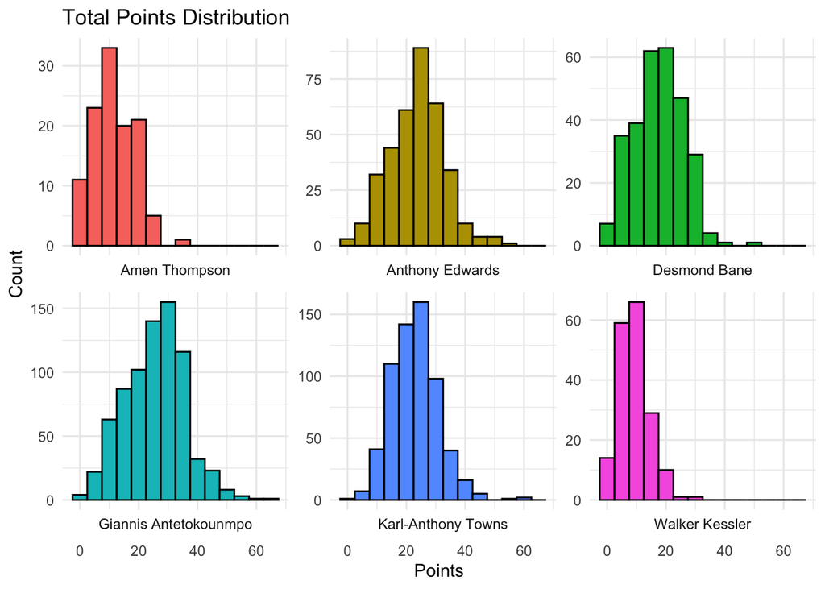

## 3.2 Total Rebounds

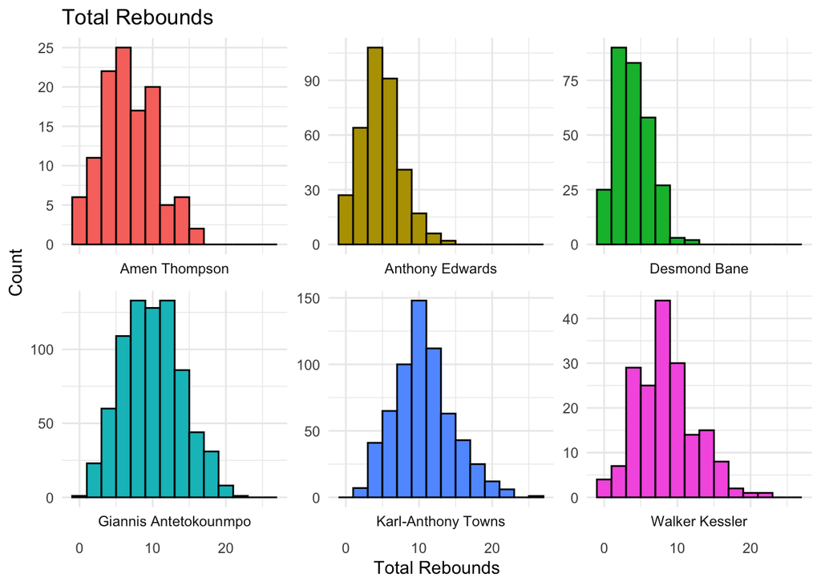

## 3.3 Total Assists

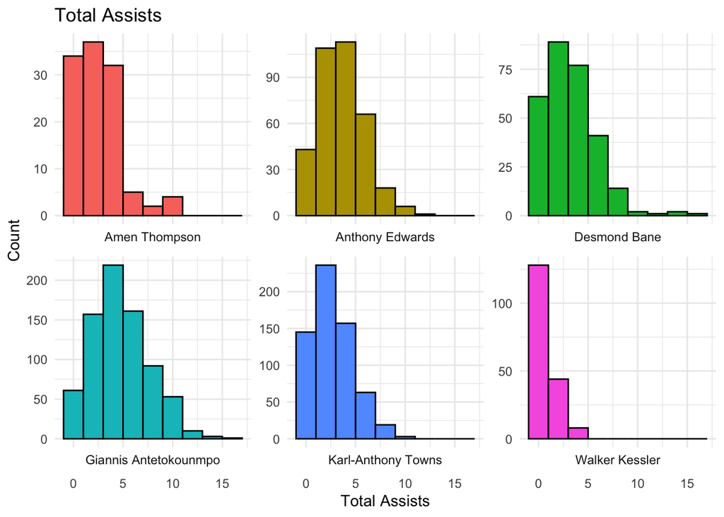

## 3.4 Total Points + Rebounds + Assists

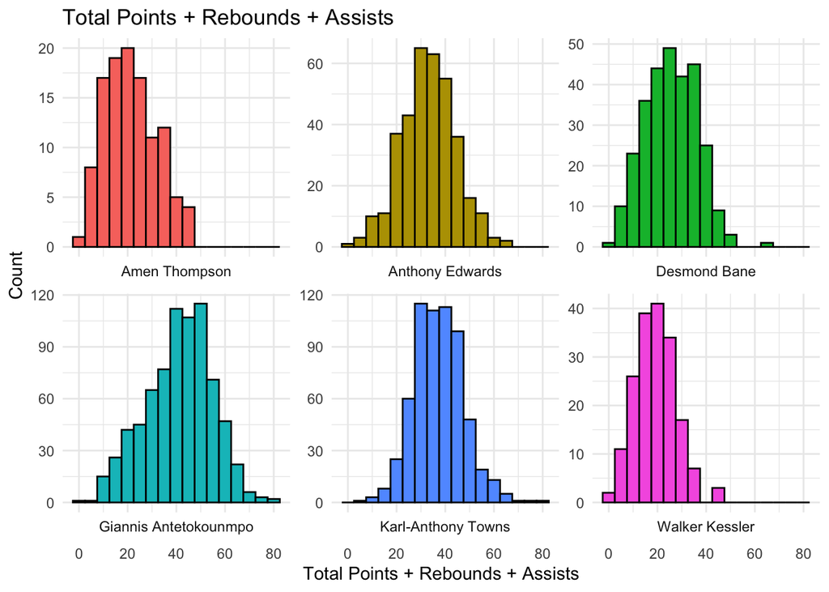

## 3.5 Total Three-Pointers Made

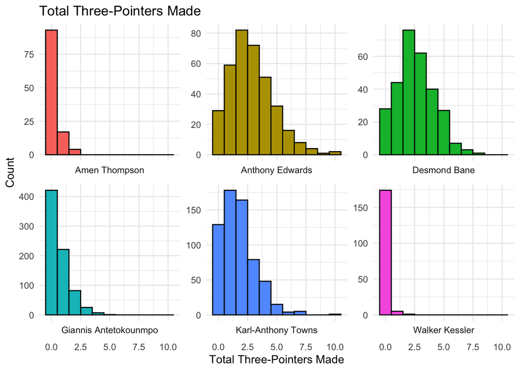

## 3.6 Total Steals + Blocks

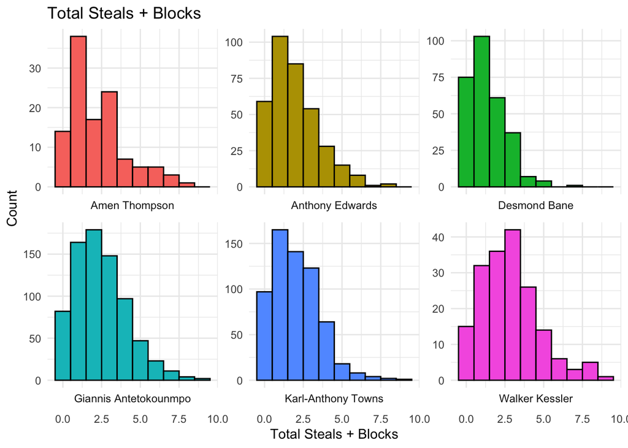

## 3.7 Total Turnovers

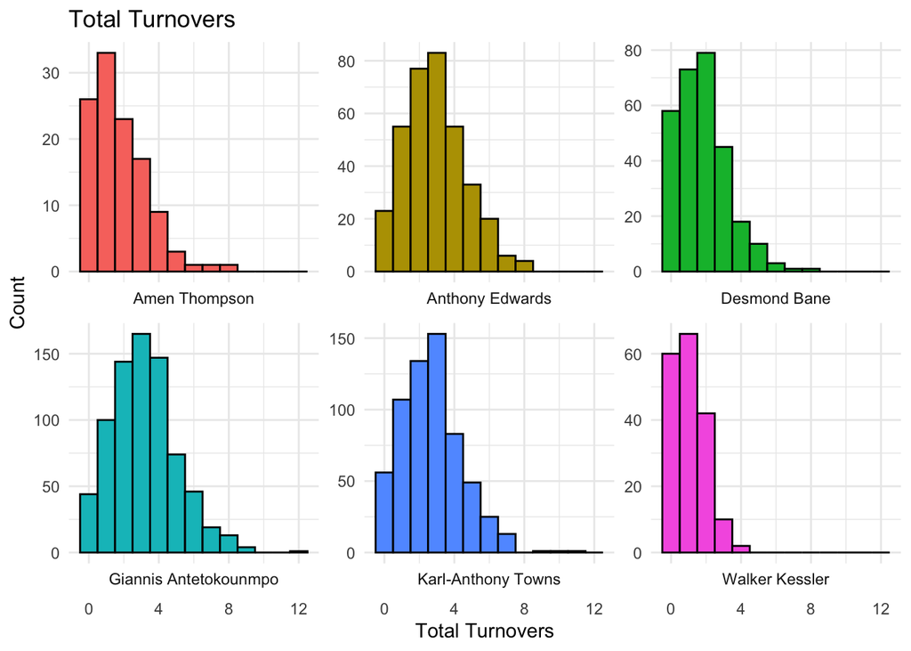

## 3.8 Total Fantasy Score

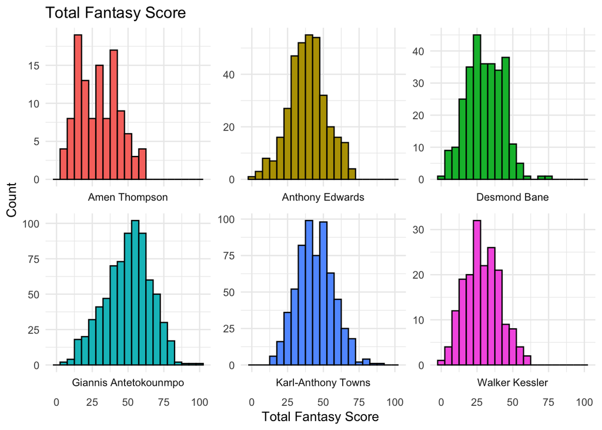

# 4 Predictions

In this section, we explore machine learning to predict basketball player performance using historical data. We aim to forecast key statistics like points, rebounds, assists, and fantasy scores with precision. These predictions provide valuable insights for fantasy basketball decisions, player evaluation, and team strategies. Whether drafting or analyzing game performance, our data-driven predictions give you a competitive edge.

## 4.1 Amen Thompson

Player: Amen Thompson | Best Prediction: 33.85 | Best Model: fantasy_score_model | Decision: Less

|  | Prediction | Projection | Threshold | Adjusted_Threshold | Five_Game_Avg | Decision |
| --- | --- | --- | --- | --- | --- | --- |
| points_model | 8.50 | 15.50 | 14.85 | 16.34 | 9.0 | Less |
| rebounds_model | 10.00 | 9.25 | 9.25 | 10.18 | NA | Less |
| assists_model | 5.07 | 4.14 | 4.14 | 4.56 | NA | More |
| total_pra_model | 28.50 | 29.50 | 28.69 | 31.56 | 21.4 | Less |
| threepm_model | 0.00 | 1.43 | 1.43 | 1.57 | NA | Less |
| stl_blk_model | 3.10 | 2.23 | 2.23 | 2.45 | NA | More |
| turnovers_model | 3.55 | 2.69 | 2.69 | 2.96 | NA | More |
| fantasy_score_model | 33.85 | 42.00 | 38.70 | 42.57 | 9.0 | Less |

## 4.2 Anthony Edwards

Player: Anthony Edwards | Best Prediction: 66.05 | Best Model: fantasy_score_model | Decision: More

|  | Prediction | Projection | Threshold | Adjusted_Threshold | Five_Game_Avg | Decision |
| --- | --- | --- | --- | --- | --- | --- |
| points_model | 47.00 | 28.50 | 29.35 | 32.29 | 37.00 | More |
| rebounds_model | 9.00 | 9.25 | 9.25 | 10.18 | NA | Less |
| assists_model | 5.22 | 4.14 | 4.14 | 4.56 | NA | More |
| total_pra_model | 59.33 | 40.50 | 41.29 | 45.42 | 48.40 | More |
| threepm_model | 6.00 | 1.43 | 1.43 | 1.57 | NA | More |
| stl_blk_model | 2.55 | 2.23 | 2.23 | 2.45 | NA | More |
| turnovers_model | 3.27 | 2.69 | 2.69 | 2.96 | NA | More |
| fantasy_score_model | 66.05 | 46.50 | 47.18 | 51.90 | 53.34 | More |

## 4.3 Desmond Bane

Player: Desmond Bane | Best Prediction: 42.82 | Best Model: fantasy_score_model | Decision: More

|  | Prediction | Projection | Threshold | Adjusted_Threshold | Five_Game_Avg | Decision |
| --- | --- | --- | --- | --- | --- | --- |
| points_model | 20.00 | 18.50 | 18.81 | 20.69 | 21.60 | Less |
| rebounds_model | 8.80 | 9.25 | 9.25 | 10.18 | NA | Less |
| assists_model | 3.97 | 4.14 | 4.14 | 4.56 | NA | Less |
| total_pra_model | 35.33 | 30.00 | 30.38 | 33.42 | 33.80 | More |
| threepm_model | 3.00 | 1.43 | 1.43 | 1.57 | NA | More |
| stl_blk_model | 1.75 | 2.23 | 2.23 | 2.45 | NA | Less |
| turnovers_model | 2.78 | 2.69 | 2.69 | 2.96 | NA | Less |
| fantasy_score_model | 42.82 | 35.00 | 35.26 | 38.79 | 37.62 | More |

## 4.4 Giannis Antetokounmpo

Player: Giannis Antetokounmpo | Best Prediction: 55.75 | Best Model: fantasy_score_model | Decision: More

|  | Prediction | Projection | Threshold | Adjusted_Threshold | Five_Game_Avg | Decision |
| --- | --- | --- | --- | --- | --- | --- |
| points_model | 34.75 | 28.50 | 28.89 | 31.78 | 32.4 | More |
| rebounds_model | 13.00 | 9.25 | 9.25 | 10.18 | NA | More |
| assists_model | 5.35 | 4.14 | 4.14 | 4.56 | NA | More |
| total_pra_model | 48.33 | 45.50 | 46.03 | 50.63 | 50.8 | Less |
| threepm_model | 0.00 | 1.43 | 1.43 | 1.57 | NA | Less |
| stl_blk_model | 1.89 | 2.23 | 2.23 | 2.45 | NA | Less |
| turnovers_model | 3.13 | 2.69 | 2.69 | 2.96 | NA | More |
| fantasy_score_model | 55.75 | 43.87 | 43.87 | 48.26 | NA | More |

## 4.5 Karl-Anthony Towns

Player: Karl-Anthony Towns | Best Prediction: 25.93 | Best Model: fantasy_score_model | Decision: Less

|  | Prediction | Projection | Threshold | Adjusted_Threshold | Five_Game_Avg | Decision |
| --- | --- | --- | --- | --- | --- | --- |
| points_model | 11.00 | 24.50 | 24.67 | 27.14 | 26.20 | Less |
| rebounds_model | 9.00 | 9.25 | 9.25 | 10.18 | NA | Less |
| assists_model | 2.38 | 4.14 | 4.14 | 4.56 | NA | Less |
| total_pra_model | 22.67 | 42.00 | 41.68 | 45.85 | 38.80 | Less |
| threepm_model | 2.20 | 1.43 | 1.43 | 1.57 | NA | More |
| stl_blk_model | 1.45 | 2.23 | 2.23 | 2.45 | NA | Less |
| turnovers_model | 1.76 | 2.69 | 2.69 | 2.96 | NA | Less |
| fantasy_score_model | 25.93 | 48.00 | 47.64 | 52.40 | 44.38 | Less |

## 4.6 Walker Kessler

Player: Walker Kessler | Best Prediction: 31.06 | Best Model: fantasy_score_model | Decision: Less

|  | Prediction | Projection | Threshold | Adjusted_Threshold | Five_Game_Avg | Decision |
| --- | --- | --- | --- | --- | --- | --- |
| points_model | 13.25 | 10.50 | 10.89 | 11.98 | 14.40 | More |
| rebounds_model | 12.33 | 9.25 | 9.25 | 10.18 | NA | More |
| assists_model | 2.30 | 4.14 | 4.14 | 4.56 | NA | Less |
| total_pra_model | 29.50 | 22.50 | 23.35 | 25.69 | 31.00 | More |
| threepm_model | 0.00 | 1.43 | 1.43 | 1.57 | NA | Less |
| stl_blk_model | 1.76 | 2.23 | 2.23 | 2.45 | NA | Less |
| turnovers_model | 2.36 | 2.69 | 2.69 | 2.96 | NA | Less |
| fantasy_score_model | 31.06 | 30.50 | 31.90 | 35.09 | 44.52 | Less |